# ESM 204 #4

Sage Kime, Karla Garibay Garcia, and Craig Stuart

5/26/2021

### 1. Quadratic Damage Function

Using damages.csv, estimate a quadratic damage function relating the dollar value of damages to the change in global mean temperature. Omit an intercept term; damages by construction must equal zero when there is no climate change. Plot your estimated damage function, overlaid with a scatterplot of the underlying data.

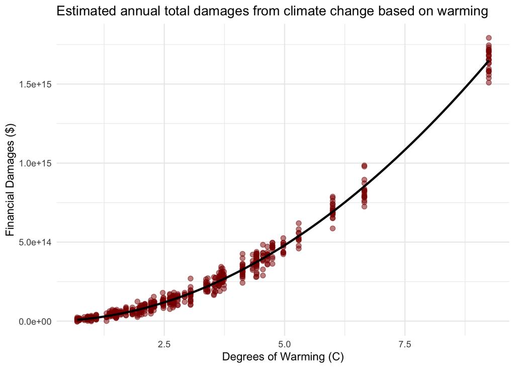

**Quadratic Damage Function: y = -1.035e12x + 1.94e13x^2**

### 2. Damages in each year under the baseline climate and pulse scenarios

Use warming.csv and your estimated damage function to predict damages in each year under the baseline climate and the pulse scenario. Make four plots: (1) damages over time without the pulse, (2) damages over time with the pulse, (3) the difference in damages over time that arises from the pulse, and (4) the difference in damages over time from the pulse per ton of CO2 (you can assume that each ton of the pulse causes the same amount of damage).

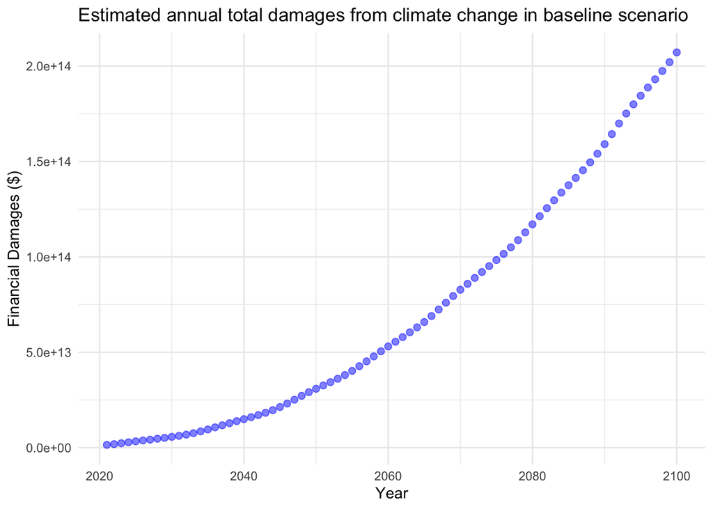

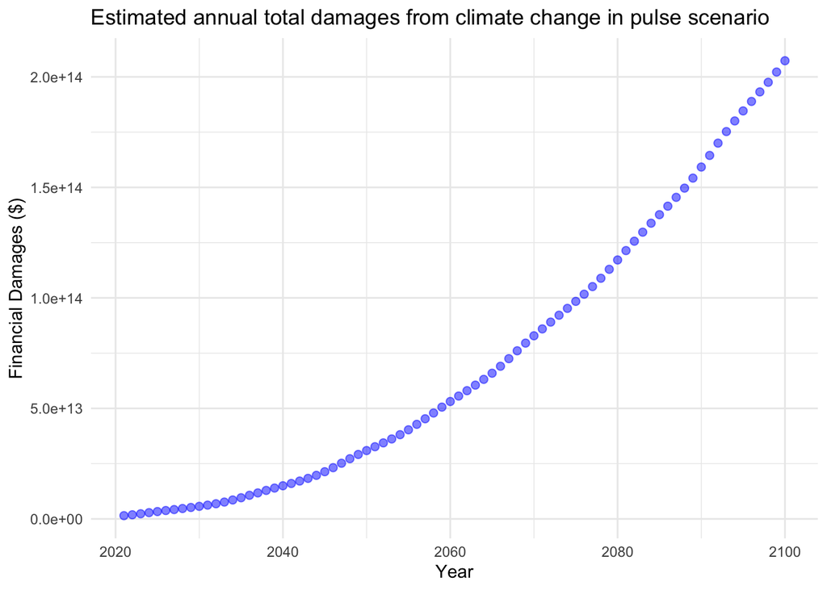

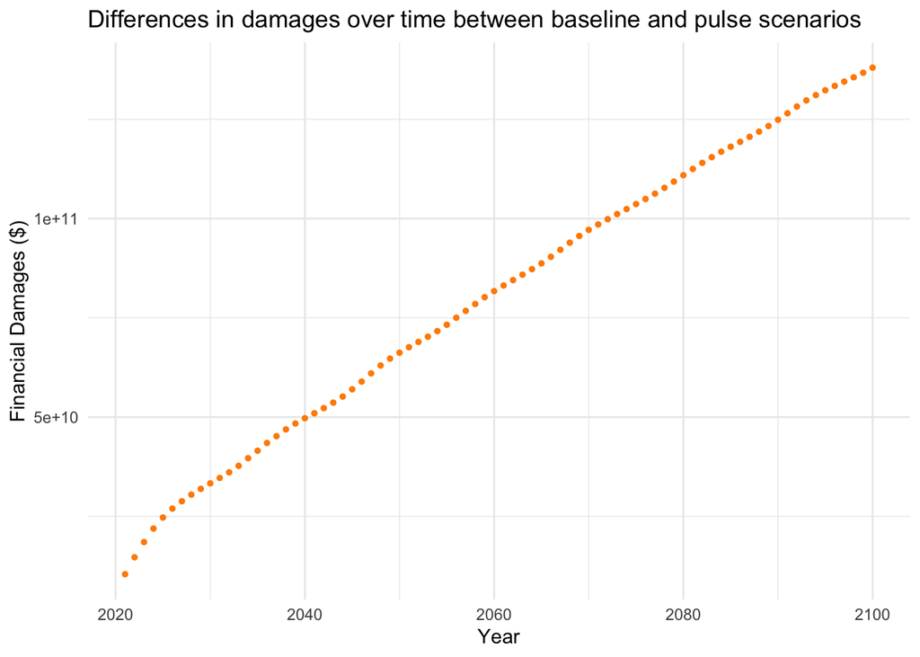

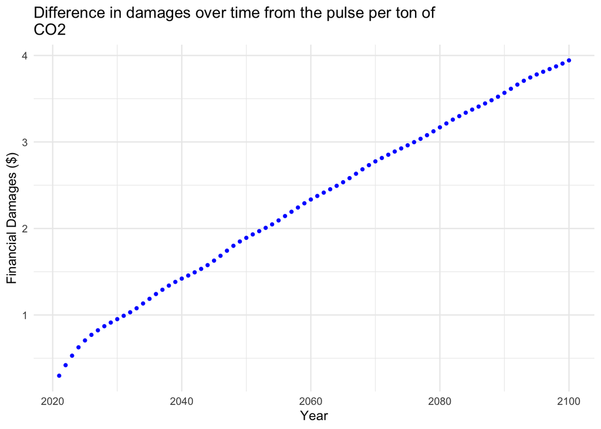

### 3. Calculate the SCC

The SCC is the present discounted value of the stream of future damages caused by one additional ton of CO2. The Obama Administration used a discount rate of 3% to discount damages. Recently, New York State used a discount rate of 2%. Calculate and make a plot of the SCC (y-axis) against the discount rate (x-axis) for a reasonable range of discount rates.

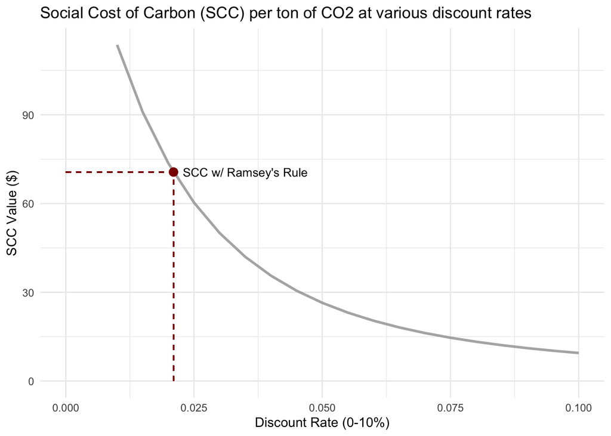

### 4. Ramsey’s Rule

The National Academies of Sciences, Engineering, and Medicine advised the government in a 2017 report to use the Ramsey Rule when discounting within the SCC calculation: r = ρ + ηg Using ρ = 0.001, η = 2, and g = 0.01, what is the SCC? Locate this point on your graph from above.

```r
#Ramsey's Rule: discount rate
r <- .001 + 2*.01

#SCC at discount rate of .021 (Ramsey's Rule)
PV_calc(warming$damages_ton, .021)
```

```
## [1] 70.65026
```

### 5. Policy A vs. Policy B

What is the expected present value of damages up to 2100 under Policy A?

```r
#Policy A

#Calculate PV using ~for loop~
PV_calc <- function(values, discount_rate) {
  sum <- 0;
  r <- discount_rate
  for (i in c(1:length(values))) {
    current <- values[i]/(1 + r)^i
    sum <- sum + current
  }
  return(sum)
}

#Create new variable for 1.5x baseline in policy A
warming$baseline150 <- warming$warming_baseline*1.5

#Create new variable for damages under 1.5 baseline outcome
warming$damages_baseline150 <- damages_model(warming$baseline150)

#Calculate PV of each outcome in policy A
A_baseline <- PV_calc(warming$damages_baseline, 0.02)
A_baseline150 <- PV_calc(warming$damages_baseline150, 0.02)

expected_value <- .5*A_baseline + .5*A_baseline150
expected_value
```

```
## [1] 3.034025e+15
```

What is the expected present value of damages up to 2100 under Policy B?

```r
#Policy B

#Create new variable for warming until 2050
warming <- warming %>%
  mutate(warming_baseline_2050 =
           case_when(year > 2050 ~ 1.29,
                     TRUE ~ warming_baseline
          ))

#Create new variable for damages under 2050 baseline outcome
warming$damages_baseline2050 <- damages_model(warming$warming_baseline_2050)

#Calculate PV of policy B
B_baseline <- PV_calc(warming$damages_baseline2050, 0.02) #PV is expected value bc only one option
B_baseline
```

```
## [1] 7.782494e+14
```

Suppose undertaking Policy A costs zero and undertaking Policy B costs X. How large could X be for it to still make economic sense to pursue Policy B instead of Policy A?

```r
#Subtract cost of policy A - policy B
max_x <- expected_value - B_baseline
max_x
```

```
## [1] 2.255776e+15
```

Qualitatively, how would your answer change if society were risk averse?